# Assingment 4

Samuel Kelly

Monday, April 26, 2021

# 8/10

# WD

```r
getwd()
```

```
## [1] "C:/Users/semyu/OneDrive/Desktop/IDE/RPackages/MATH4753Kelly/MATH4753-Applied Statistical Methods/Assessments/Assessment 4"
```

# 1. MS 7.118 - pg 364

116 bird species, measured were body mass(g), egg length(mm)

## a.

```r
nzbird=read.csv("NZBIRDS.csv")
head(nzbird)
```

|  | ï..Species | Name | Extinct | Habitat | Nest.Site | Nest.Density | Diet | Flight | Body.Mass | Egg.Length |
| --- | --- | --- | --- | --- | --- | --- | --- | --- | --- | --- |
| 1 | Grebes | P. cristatus | No | A | G | L | F | Yes | 1100 | 57 |
| 2 | Grebes | P. rufopectus | No | A | G | L | F | Yes | 250 | 43 |
| 3 | Petrels | P. gavia | Yes | A | GC | H | F | Yes | 300 | 57 |
| 4 | Petrels | P. huttoni | Absent | A | GC | H | F | Yes | 350 | 60 |
| 5 | Petrels | P. spelaeus | Absent | A | GC | H | F | Yes | 250 | 55 |
| 6 | Petrels | P. assimilis | Yes | A | GC | H | F | Yes | 200 | 54 |

```r
set.seed(50)
sam=nzbird[sample(1:nrow(nzbird),size = 35),]
```

## b.

Body mass

```r
mean(sam$Body.Mass)
```

```
## [1] 6680.371
```

```r
sd(sam$Body.Mass)
```

```
## [1] 26369.59
```

```r
t.test(x = nzbird$Body.Mass,conf.level = .95,mu = 6680.371)$conf.int
```

```
## [1]  3208.217 13397.434
## attr(,"conf.level")
## [1] 0.95
```

## c.

We accept our null hypothesis that the mean of our sample, 6680.371g, is in the confidence interval of (3208.217, 13397.434), since 6680.371 is in this interval.

## d.

The true mean of 9113g is in the interval (3208.217, 13397.434). The confidence level we have chosen is alpha=.05, or 95% confidence, and since 95% covers most of the data set, we can be fairly certain that the true mean lies in the interval.

## e.

Egg length

```r
mean(sam$Egg.Length,na.rm = T)
```

```
## [1] 55.5303
```

```r
sd(sam$Egg.Length,na.rm = T)
```

```
## [1] 41.82963
```

```r
t.test(x = nzbird$Egg.Length,conf.level = .95,mu = 55.5303)$conf.int
```

```
## [1] 53.02102 68.28667
## attr(,"conf.level")
## [1] 0.95
```

We accept the null hypothesis that 55.5303 is in the interval (53.02102, 68.28667). 61.06 is also in our interval, and since we cover 95% of the data we can be fairly certain that the true mean lies n the interval.

## f.

```r
flight_extinct=21/38
flight_alive=7/78
z=qnorm(1-.05/2)
np=38*flight_extinct
np>=4
```

```
## [1] TRUE
```

```r
nq=38*(1-flight_extinct)
nq>=4
```

```
## [1] TRUE
```

```r
np2=78*flight_alive
np2>=4
```

```
## [1] TRUE
```

```r
nq2=78*(1-flight_alive)
nq2>=4
```

```
## [1] TRUE
```

Since our approximations are greater than or equal to 4, than we can use CLT.

```r
mp=c(-1,1)
(flight_extinct-flight_alive)+mp*z*sqrt((flight_extinct*(1-flight_extinct))/38+(flight_alive*(1-flight_alive))/78)
```

```
## [1] 0.2925475 0.6332285
```

Our 95% ci is (0.2925475, 0.6332285).

## g.

Yes, we 95% confident that 21/38=.5526 lies in the interval while 7/78=.0897 does not, so the proportion of extinct birds is higher.

# 2. MS 7.120 - pg 365

## a.

n1=100, n2=47 are both greater than 30, so we know which 2-sample formula to use.
$$(\bar{y_1}-\bar{y_2})\pm z_{\frac{\alpha}{2}}\sqrt{\frac{s_1^2}{n_1}+\frac{s_2^2}{n_2}}$$

```r
(1312-1352)+mp*qnorm(1-.1/2)*sqrt((422^2)/100+(271^2)/47)
```

```
## [1] -135.10916   55.10916
```

## b.

$$(\frac{s_1^2}{s_2^2})\frac{1}{F_{\alpha/2(\nu_1,\nu_2)}}\leq \frac{\sigma_1^2}{\sigma_2^2}\leq (\frac{s_1^2}{s_2^2})F_{\alpha/2(\nu_2,\nu_1)}$$

```r
f1=qf(1-.1/2,df1 = 99,df2 = 46)
f2=qf(1-.1/2,df1 = 46,df2 = 99)
l=(422^2)/271^2*(1/f1)
u=(422^2)/271^2*(f2)
ci=c(l,u)
ci
```

```
## [1] 1.566267 3.617750
```

We can say that the variances do indeed differ as 1 is not in the interval (1.566267, 3.617750).

# 3. MS 7.128 - pg 367

## a.

## b.

# 4. MS 8.24 - pg 390

## a.

The Null Hypothesis is mu=2, the alternative hypothesis is that mu!=2.

## b.

The t statistic is -1.02, and the p-value is .322

## c.

```r
qt(1-.05/2,df = 19)
```

```
## [1] 2.093024
```

We reject when the t statistic falls in the interval (-infinity,-2.093024)U(2.093024,infinity)

## d.

We accept mu=2 as a possible value. Not only does t lie in the ci, but our p-value is greater than alpha, .322>.05.

## e.

Since our test statistic t lies in the 95% ci, then we can conclude that we are fairly certain our mean lies in the interval.

# 5. MS 8.28 - pg 392

## a.

```r
lake=c(9.6,4.5,13.2,4.1,22.6,2.7,14.7,3.5,13.6,19.8,14.3,56.9,25.1,18.4,2.7,4.2,30.2,10.3,17.6,2.4,17.3,38.8,3.0,5.8,7.6)
t.test(x = lake,mu = 15,conf.level = .9)
```

```
##
##  One Sample t-test
##
## data:  lake
## t = -0.18668, df = 24, p-value = 0.8535
## alternative hypothesis: true mean is not equal to 15
## 90 percent confidence interval:
##  10.08013 18.95187
## sample estimates:
## mean of x
##    14.516
```

With the t test we can see that our p-value is .8535>.1 so we can accept our null hypothesis, and since the estimate mean is 14.516, we can say that this sample may closely reflect all of Wisconsin.

## b.

$$t=\frac{\bar{y}-\mu_0}{s/\sqrt n}\Rightarrow \bar{y}=t\frac{s}{\sqrt n}+\mu_0$$

```r
s=sd(lake)
t=qt(1-.1/2,df = 24)
mu=15
ci=mp*t*(s/sqrt(25))+mu
ci
```

```
## [1] 10.56413 19.43587
```

We would reject the null if mu fell into the region (-infinity,10.56413)U(19.43587,infinity). So the probability that t will lie in that region is:

```r
pt((10.56413-14)/(s/sqrt(25)),df = 24) + (1-pt((19.43587-14)/(s/sqrt(25)),df = 24))
```

```
## [1] 0.1221687
```

The probability that t will be in the rejection region is: 12.21687%.

# 6. MS 8.44 - pg 401

```r
orch=read.csv("ORCHARD.csv")
head(orch)
```

|  | ï..DAY | CONDITION | THION | OXON | RATIO |
| --- | --- | --- | --- | --- | --- |
| 1 | 15 | FOG | 38.2 | 10.3 | 0.270 |
| 2 | 17 | FOG | 28.6 | 6.9 | 0.241 |
| 3 | 18 | FOG | 30.2 | 6.2 | 0.205 |
| 4 | 19 | FOG | 23.7 | 12.4 | 0.523 |
| 5 | 20 | FOG | 62.3 | NA | NA |
| 6 | 20 | CLEAR | 74.1 | 45.8 | 0.618 |

```r
library(dplyr)
dim(orch)
```

```
## [1] 13  5
```

```r
filter(orch,CONDITION == "FOG")
```

| ï..DAY | CONDITION | THION | OXON | RATIO |
| --- | --- | --- | --- | --- |
| 15 | FOG | 38.2 | 10.3 | 0.270 |
| 17 | FOG | 28.6 | 6.9 | 0.241 |
| 18 | FOG | 30.2 | 6.2 | 0.205 |
| 19 | FOG | 23.7 | 12.4 | 0.523 |
| 20 | FOG | 62.3 | NA | NA |
| 21 | FOG | 88.2 | 9.9 | 0.112 |
| 22 | FOG | 135.9 | 44.8 | 0.330 |
| 23 | FOG | 102.9 | 27.8 | 0.270 |
| 25 | FOG | 46.9 | 11.2 | 0.239 |

```r
filter(orch,CONDITION == "CLEAR"|CONDITION=="CLOUD")
```

| ï..DAY | CONDITION | THION | OXON | RATIO |
| --- | --- | --- | --- | --- |
| 20 | CLEAR | 74.1 | 45.8 | 0.618 |
| 21 | CLEAR | 46.4 | 27.4 | 0.591 |
| 23 | CLOUD | 28.9 | 6.5 | 0.225 |
| 25 | CLEAR | 44.3 | 16.6 | 0.375 |

```r
dfog=with(orch,orch[CONDITION == "FOG",])
dfclcloud=with(orch, orch[CONDITION == "CLEAR" | CONDITION == "CLOUD",])
dfog
```

|  | ï..DAY | CONDITION | THION | OXON | RATIO |
| --- | --- | --- | --- | --- | --- |
| 1 | 15 | FOG | 38.2 | 10.3 | 0.270 |
| 2 | 17 | FOG | 28.6 | 6.9 | 0.241 |
| 3 | 18 | FOG | 30.2 | 6.2 | 0.205 |
| 4 | 19 | FOG | 23.7 | 12.4 | 0.523 |
| 5 | 20 | FOG | 62.3 | NA | NA |
| 7 | 21 | FOG | 88.2 | 9.9 | 0.112 |
| 9 | 22 | FOG | 135.9 | 44.8 | 0.330 |
| 10 | 23 | FOG | 102.9 | 27.8 | 0.270 |
| 12 | 25 | FOG | 46.9 | 11.2 | 0.239 |

```r
dfclcloud
```

|  | ï..DAY | CONDITION | THION | OXON | RATIO |
| --- | --- | --- | --- | --- | --- |
| 6 | 20 | CLEAR | 74.1 | 45.8 | 0.618 |
| 8 | 21 | CLEAR | 46.4 | 27.4 | 0.591 |
| 11 | 23 | CLOUD | 28.9 | 6.5 | 0.225 |
| 13 | 25 | CLEAR | 44.3 | 16.6 | 0.375 |

```r
fog_rat=subset(orch,CONDITION == "FOG", RATIO)
cc_rat=subset(orch,CONDITION == "CLOUD" | CONDITION == "CLEAR", RATIO)
orch=mutate(orch,Cond=recode(CONDITION,CLOUD="CLCL",CLEAR="CLCL"))
orch
```

| ï..DAY | CONDITION | THION | OXON | RATIO | Cond |
| --- | --- | --- | --- | --- | --- |
| 15 | FOG | 38.2 | 10.3 | 0.270 | FOG |
| 17 | FOG | 28.6 | 6.9 | 0.241 | FOG |
| 18 | FOG | 30.2 | 6.2 | 0.205 | FOG |
| 19 | FOG | 23.7 | 12.4 | 0.523 | FOG |
| 20 | FOG | 62.3 | NA | NA | FOG |
| 20 | CLEAR | 74.1 | 45.8 | 0.618 | CLCL |
| 21 | FOG | 88.2 | 9.9 | 0.112 | FOG |
| 21 | CLEAR | 46.4 | 27.4 | 0.591 | CLCL |
| 22 | FOG | 135.9 | 44.8 | 0.330 | FOG |
| 23 | FOG | 102.9 | 27.8 | 0.270 | FOG |

[output cut: 3 more lines]

```r
t.test(RATIO ~ Cond,data = orch,mu=0,var.equal=T)
```

```
##
##  Two Sample t-test
##
## data:  RATIO by Cond
## t = 2.0467, df = 10, p-value = 0.06788
## alternative hypothesis: true difference in means is not equal to 0
## 95 percent confidence interval:
##  -0.01581919  0.37281919
## sample estimates:
## mean in group CLCL  mean in group FOG
##            0.45225            0.27375
```

```r
qt(1-.05/2,df = 8+4-2)
```

```
## [1] 2.228139
```

Since our t statistic 2.0467 does not fall outside the rejection region of -2.228139 or 2.228139 then we do not reject the null hypothesis that mu0-mu1=0. The p-value also backs this up since .06788>.05.

# 7. MS 8.84 - pg 425 – This refers to 8.39 NOT 8.33!

## a.

```r
gt=read.csv("GASTURBINE.csv")
head(gt)
```

|  | ï..ENGINE | SHAFTS | RPM | CPRATIO | INLET.TEMP | EXH.TEMP | AIRFLOW | POWER | HEATRATE | LHV. | ISOWORK |
| --- | --- | --- | --- | --- | --- | --- | --- | --- | --- | --- | --- |
| 1 | Traditional | 1 | 27245 | 9.2 | 1134 | 602 | 7 | 1630 | 14622 | 24.6 | 232.86 |
| 2 | Traditional | 1 | 14000 | 12.2 | 950 | 446 | 15 | 2726 | 13196 | 27.3 | 181.73 |
| 3 | Traditional | 1 | 17384 | 14.8 | 1149 | 537 | 20 | 5247 | 11948 | 30.1 | 262.35 |
| 4 | Traditional | 1 | 11085 | 11.8 | 1024 | 478 | 27 | 6726 | 11289 | 31.9 | 249.11 |
| 5 | Traditional | 1 | 14045 | 13.2 | 1149 | 553 | 29 | 7726 | 11964 | 30.1 | 266.41 |
| 6 | Traditional | 1 | 6211 | 15.7 | 1172 | 517 | 176 | 52600 | 10526 | 34.2 | 298.86 |

```r
gtrad=filter(gt,ï..ENGINE == "Traditional")
gae=filter(gt,ï..ENGINE == "Aeroderiv")
gad=filter(gt,ï..ENGINE == "Advanced")
var.test(x = gtrad$HEATRATE,y = gae$HEATRATE,conf.level = .95,ratio = 1)
```

```
##
##  F test to compare two variances
##
## data:  gtrad$HEATRATE and gae$HEATRATE
## F = 0.23272, num df = 38, denom df = 6, p-value = 0.004234
## alternative hypothesis: true ratio of variances is not equal to 1
## 95 percent confidence interval:
##  0.04635082 0.64308536
## sample estimates:
## ratio of variances
##          0.2327207
```

```r
qf(c(.05/2,1-.05/2),df1 = 6,df2 = 38)
```

```
## [1] 0.1991693 2.7633350
```

## b.

```r
var.test(x = gad$HEATRATE,y = gae$HEATRATE,conf.level = .95,ratio = 1)
```

```
##
##  F test to compare two variances
##
## data:  gad$HEATRATE and gae$HEATRATE
## F = 0.057974, num df = 20, denom df = 6, p-value = 1.192e-06
## alternative hypothesis: true ratio of variances is not equal to 1
## 95 percent confidence interval:
##  0.0112170 0.1813622
## sample estimates:
## ratio of variances
##         0.05797393
```

```r
qf(c(.05/2,1-.05/2),df1 = 6,df2 = 20)
```

```
## [1] 0.1934834 3.1283400
```

There is an even greater divide between these heat rates, as .05> 1.192e-06, and F is not in our ci. The heat rates of the two engines are significantly different.

# 8. MS 8.99 - pg 438

## a.

## b.

## c.

## d.

## e.

## f.

# 9. MS 8.104 - pg 439

```r
human=c(185.4,146.3,174.4,184.9,240,253.8,238.8,263.5)
robot=c(180.4,248.5,185.5,216.4,269.3,249.6,282,315.9)
t.test(x = human,y = robot,paired = T,conf.level = .95)
```

```
##
##  Paired t-test
##
## data:  human and robot
## t = -2.629, df = 7, p-value = 0.03396
## alternative hypothesis: true difference in means is not equal to 0
## 95 percent confidence interval:
##  -61.850346  -3.274654
## sample estimates:
## mean of the differences
##                -32.5625
```

```r
qt(c(.05/2,1-.05/2),df = 7)
```

```
## [1] -2.364624  2.364624
```

The t test clearly shows that mu1-mu2 does not equal to 0, and this is supported by the p-value .03396<.05, and t lying in the rejection region. Since our estimate is negative, then our mean must be greater for mu2, so the robots clearly took more time than their human counterparts, so the humans were more efficient in their work.

# 10. Plot

```r
set.seed(35) # This will give everyone the same sample
sam=round(rnorm(30,mean=20,sd=3),3)
unique(sample(sam,30,replace=TRUE) )
```

```
##  [1] 21.232 19.038 18.963 21.461 21.703 18.821 21.049 23.574 19.865 23.006
## [11] 23.195 18.313 14.664 21.535 14.274 22.593 17.695 20.399 30.014 21.336
## [21] 21.047 19.898
```

```r
sample(sam,30,replace=FALSE)
```

```
##  [1] 19.898 22.053 20.399 23.195 25.515 21.535 17.695 21.703 21.659 30.014
## [11] 18.963 23.006 25.019 19.038 18.497 21.232 14.274 21.049 21.735 19.865
## [21] 22.593 23.829 22.871 14.664 21.047 18.313 23.574 21.336 18.821 21.461
```

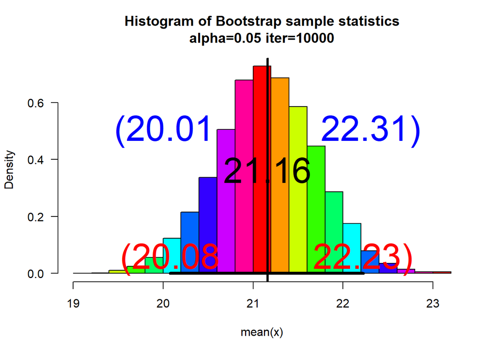

```
## $ci
##     2.5%    97.5%
## 20.07910 22.22545
##
## $fun
## function(x) mean(x)
## <bytecode: 0x00000000127a7520>
##
## $x
##  [1] 23.195 20.399 19.898 19.865 30.014 18.821 21.232 18.313 23.574 21.047
## [11] 21.535 21.336 17.695 18.497 14.274 14.664 22.593 18.963 25.515 25.019
## [21] 22.053 22.871 23.006 23.829 19.038 21.735 21.461 21.659 21.703 21.049
##
## $t
## [1] 2.04523
##
## $cit
## [1] 20.01155 22.31198
```

```r
myboot<-function(iter=10000,x,fun="mean",alpha=0.05,...){  #Notice where the ... is repeated in the code
n=length(x)   #sample size

y=sample(x,n*iter,replace=TRUE)
rs.mat=matrix(y,nr=n,nc=iter,byrow=TRUE)
xstat=apply(rs.mat,2,fun) # xstat is a vector and will have iter values in it
ci=quantile(xstat,c(alpha/2,1-alpha/2))# Nice way to form a confidence interval
# A histogram follows
# The object para will contain the parameters used to make the histogram
para=hist(xstat,freq=FALSE,las=1,
main=paste("Histogram of Bootstrap sample statistics","\n","alpha=",alpha," iter=",iter,sep=""),
...)

#mat will be a matrix that contains the data, this is done so that I can use apply()
mat=matrix(x,nr=length(x),nc=1,byrow=TRUE)

#pte is the point estimate
#This uses whatever fun is
pte=apply(mat,2,fun)
abline(v=pte,lwd=3,col="Black")# Vertical line

t=qt(1-alpha/2,df = n-1)
cit=mp*t*(sd(x)/sqrt(n))+mean(x)

segments(ci[1],0,ci[2],0,lwd=4)      #Make the segment for the ci
text(ci[1],.05,paste("(",round(ci[1],2),sep=""),col="Red",cex=3)
text(ci[2],.05,paste(round(ci[2],2),")",sep=""),col="Red",cex=3)

text(cit[1],.5,paste("(",round(cit[1],2),sep=""),col="Blue",cex=3)
text(cit[2],.5,paste(round(cit[2],2),")",sep=""),col="Blue",cex=3)

# plot the point estimate 1/2 way up the density
text(pte,max(para$density)/2,round(pte,2),cex=3)

return(list(ci=ci,fun=fun,x=x,t=t,cit=cit))# Some output to use if necessary
}

myboot(10000,x=sam,fun=function(x) mean(x),alpha=0.05,xlab="mean(x)",col=rainbow(10))
```

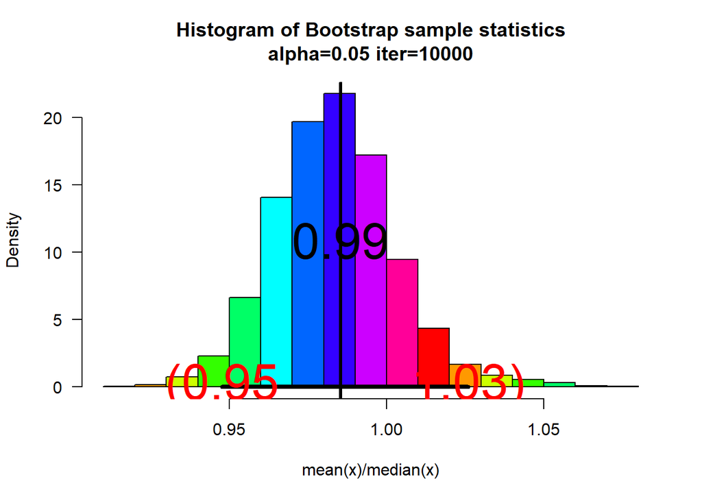

```
## $ci
##      2.5%     97.5%
## 0.9477059 1.0259472
##
## $fun
## function(x) mean(x)/median(x)
## <bytecode: 0x00000000126dbb28>
##
## $x
##  [1] 20.71089 19.92985 15.62876 20.62380 18.54635 23.74239 22.35607 18.00489
##  [9] 26.50992 21.04061 22.49841 18.74725 16.36348 22.21449 25.48783 15.25663
## [17] 22.29764 16.02664 21.99929 22.21293 20.66434 19.83704 21.80781 21.98428
## [25] 20.01782 18.37267 21.34548 15.88817 23.37508 18.06163
##
## $t
## [1] 2.04523
##
## $cit
## [1] 19.31677 21.45340
```

```r
sam=rnorm(30,mean=20,sd=3)
myboot(10000,x=sam,fun=function(x) mean(x)/median(x),alpha=0.05,xlab="mean(x)/median(x)",col=rainbow(10))
```

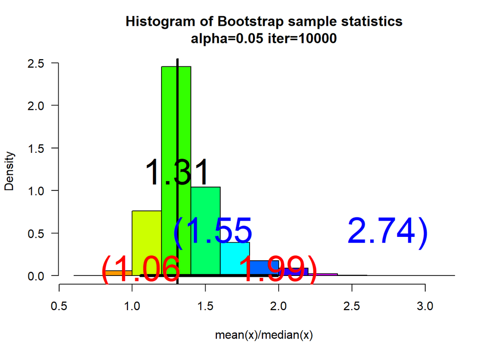

```
## $ci
##     2.5%    97.5%
## 1.056187 1.990058
##
## $fun
## function(x) mean(x)/median(x)
## <bytecode: 0x000000001c214198>
##
## $x
##  [1] 1.18174426 3.61143625 0.83457721 1.34953910 2.16732155 1.81470710
##  [7] 0.43350419 0.88297915 6.71177363 1.44786061 4.74076236 0.60650528
## [13] 0.13577504 7.01710481 0.06351964 4.02564082 0.24276471 1.58121742
## [19] 3.02904448 2.10409429 0.58140926 4.22253920 4.09408002 0.37940867
## [25] 4.59760945 0.25924635 4.49666164 1.87555003 1.75020165 1.69921002
## [31] 0.87575966 0.70523174 0.48502551 3.09743716 3.83506349 1.02882997
## [37] 0.17451199 4.78432023 2.61187956 0.26900067
##
## $t
## [1] 2.022691
##
## $cit
## [1] 1.547656 2.742587
```

```r
sam=rchisq(40,df=2)
myboot(10000,x=sam,fun=function(x) mean(x)/median(x),alpha=0.05,xlab="mean(x)/median(x)",col=rainbow(10))
```